# bayesDREAM vignette: fit_cis for a CRISPRi screen, memory-lean per-gene files

Builds on `vignette_ntc_fit_crispri.py` (technical/NTC fit). This vignette covers the **second stage** — `fit_cis()` — for a scenario where:

- You already ran `fit_ntc()` **once**, transcriptome-wide, on NTC cells only, and saved it (previous vignette).
- You do **not** keep one giant genes x all-cells counts matrix around. Instead you have, on disk: one **NTC-cells-only** counts file (all genes) and, **separately, one small counts file per candidate cis gene** (all genes, but only *that gene's own* guide-targeting cells) — so fitting gene G never requires loading any other gene's guide cells into memory.
- You have the **full cohort metadata** in one place and subset it, per gene, to whichever cells that gene's counts file actually contains.
- Two equally-valid ways to tell bayesDREAM which guide targets which gene are covered: a `guide_target` DataFrame, or a precomputed `target` column in `meta`.
- You test on **GFI1B** first, measure real memory usage, then generate a SLURM **array job** for the rest of the candidate genes on **Dardel**.

Run top to bottom as a script, or cell-by-cell (the `# %%` markers).

```python
import os
import sys
import math
import resource
from pathlib import Path

import numpy as np
import pandas as pd
import torch
import pyro
import matplotlib.pyplot as plt
import matplotlib.colors as mcolors
import yaml

deviceno = 0
device = torch.device(f'cuda:{deviceno}' if torch.cuda.is_available() else 'cpu')

from bayesDREAM import bayesDREAM
```

## Reproducibility

```python
SEED = 20260807
rng = np.random.default_rng(SEED)
np.random.seed(SEED)
torch.manual_seed(SEED)
pyro.set_rng_seed(SEED)


def find_repo_root(start: str = ".") -> str:
    """Walk upward from `start` until a directory containing `publication_runs/`
    is found — robust to whatever the notebook's/script's cwd happens to be."""
    p = os.path.abspath(start)
    while not os.path.isdir(os.path.join(p, "publication_runs")):
        parent = os.path.dirname(p)
        if parent == p:
            raise RuntimeError("Could not find repo root (no publication_runs/ found above cwd)")
        p = parent
    return p


REPO_ROOT = find_repo_root()
OUTDIR = os.path.join(REPO_ROOT, "examples", "output_vignette_cis")
DATADIR = os.path.join(OUTDIR, "data")
os.makedirs(DATADIR, exist_ok=True)
print(f"REPO_ROOT = {REPO_ROOT}")
print(f"OUTDIR    = {OUTDIR}")
```

```
REPO_ROOT = /Users/leahrosen/Library/Mobile Documents/com~apple~CloudDocs/Documents/Postdoc/Code/bayesDREAM code/bayesDREAM_forClaude
OUTDIR    = /Users/leahrosen/Library/Mobile Documents/com~apple~CloudDocs/Documents/Postdoc/Code/bayesDREAM code/bayesDREAM_forClaude/examples/output_vignette_cis
```

## Simulate the memory-lean file layout

`HHEX` is deliberately set low enough that, after `fit_ntc()`'s shrinkage for sparse/lowly-expressed genes, its *fitted* `log2(mu_ntc)` lands in `[-1.5, -1)` — kept, but needs `force=True` (`fit_cis()`'s own built-in gate is at -1; our lab convention here is more lenient, at -1.5). `FillerD` is set low enough to land clearly below -1.5 — excluded entirely, never submitted. Exactly which other candidates land in the force band vs. get excluded is a real, data-dependent outcome of the fit below (`FillerA` in particular is deliberately borderline too) — the printed table after fitting is the actual source of truth, not this comment.

We then simulate the **whole** cohort once (for internal consistency), but only ever *write to disk* — and later *read back* — the NTC-only block and each gene's own block, exactly mirroring what a real memory-lean layout would give you. Nothing downstream reads "some other gene's guide cells" out of this in-memory array; that would defeat the point of the exercise.

```python
N_BATCHES = 12
N_NTC_PER_BATCH = 25
N_BACKGROUND_GENES = 300
N_GUIDES_PER_TARGET = 3
N_CELLS_PER_GUIDE = 20

BATCHES = [f"batch{i + 1}" for i in range(N_BATCHES)]
batch_effect = {b: float(np.exp(rng.normal(0, 0.25))) for b in BATCHES}

NAMED_GENES = ["GFI1B", "NFE2", "MYB", "TET2", "IKZF1", "HHEX", "RUNX1"]
FILLER_GENES = ["FillerA", "FillerB", "FillerD"]
CANDIDATE_GENES = NAMED_GENES + FILLER_GENES

# hand-set NTC mean expression (mu) per candidate gene -- log2(mu) shown alongside
CANDIDATE_MU = {
    "GFI1B":   3.00,   # log2 =  1.58
    "NFE2":    2.00,   # log2 =  1.00
    "MYB":     1.50,   # log2 =  0.58
    "TET2":    1.00,   # log2 =  0.00
    "IKZF1":   1.30,   # log2 =  0.38
    "HHEX":    0.44,   # log2 = -1.18  -- fit_ntc's shrinkage for sparse/lowly-expressed
                       #                  genes pulls the *fitted* log2(mu_ntc) well below
                       #                  this true value at our small NTC-per-batch count;
                       #                  lands in [-1.5, -1) after fitting -- kept, needs force=True
    "RUNX1":   0.90,   # log2 = -0.15
    "FillerA": 0.35,   # log2 = -1.51  -- borderline like HHEX; see printed table for outcome
    "FillerB": 2.20,   # log2 =  1.14
    "FillerD": 0.22,   # log2 = -2.18  -- comfortably below -1.5: excluded
}
for g, mu in CANDIDATE_MU.items():
    print(f"  {g:10s} true log2(mu_ntc) = {np.log2(mu):+.2f}")

background_genes = [f"Gene{i:04d}" for i in range(N_BACKGROUND_GENES)]
ALL_GENES = CANDIDATE_GENES + background_genes
gene_index = {g: i for i, g in enumerate(ALL_GENES)}

# Dedicated RNG stream for background-gene mu/dispersion, decoupled from the
# `rng` used for cell/guide simulation below -- so hand-tuning a candidate
# gene's true mu (to land its *fitted* log2(mu_ntc) in a specific band after
# fit_ntc's shrinkage) doesn't ripple into every other gene's simulated draw.
rng_bg = np.random.default_rng(SEED + 1)
mu_background = np.exp(rng_bg.normal(loc=0.3, scale=1.4, size=N_BACKGROUND_GENES))
mu_gene = dict(zip(ALL_GENES, [CANDIDATE_MU[g] for g in CANDIDATE_GENES] + list(mu_background)))
o_y_gene = {g: float(rng_bg.uniform(0.15, 0.5)) for g in ALL_GENES}

# --- NTC cells ---
ntc_rows = [
    {"cell": f"ntc_{b}_{i}", "guide": f"sgNTC_{(i % 3) + 1}", "target": "ntc", "batch": b}
    for b in BATCHES for i in range(N_NTC_PER_BATCH)
]

# --- per-candidate-gene guide cells, with per-guide (not just per-gene)
#     knockdown potency, so "minimum log2FC across a gene's own guides" is
#     a meaningful, non-degenerate quantity ---
guide_rows = []
guide_fc = {}  # (gene, guide) -> residual fraction of NTC mean
for gene in CANDIDATE_GENES:
    mean_fc = float(rng.uniform(0.20, 0.40))
    for g_idx in range(N_GUIDES_PER_TARGET):
        guide_name = f"sg{gene}_{g_idx + 1}"
        fc = float(np.clip(mean_fc * np.exp(rng.normal(0, 0.20)), 0.05, 0.9))
        guide_fc[(gene, guide_name)] = fc
        for i in range(N_CELLS_PER_GUIDE):
            b = rng.choice(BATCHES)
            guide_rows.append({"cell": f"{guide_name}_{i}", "guide": guide_name, "target": gene, "batch": b})

meta_full = pd.DataFrame(ntc_rows + guide_rows)
meta_full["sum_factor"] = rng.uniform(0.7, 1.3, size=len(meta_full))

# --- simulate counts (vectorised NegBinom draw), full cohort ---
mu_vec = np.array([mu_gene[g] for g in ALL_GENES])
o_vec = np.array([o_y_gene[g] for g in ALL_GENES])
batch_vec = meta_full["batch"].map(batch_effect).values.astype(float)
sf_vec = meta_full["sum_factor"].values.astype(float)
mean_mat = np.outer(mu_vec, batch_vec * sf_vec)

for (gene, guide_name), fc in guide_fc.items():
    gi = gene_index[gene]
    cell_mask = (meta_full["guide"].values == guide_name)
    mean_mat[gi, cell_mask] *= fc

phi_vec = 1.0 / (o_vec ** 2)
phi_mat = np.tile(phi_vec[:, None], (1, mean_mat.shape[1]))
p_mat = phi_mat / (phi_mat + mean_mat)
counts_full = pd.DataFrame(
    rng.negative_binomial(phi_mat, p_mat), index=ALL_GENES, columns=meta_full["cell"].values
)
gene_meta = pd.DataFrame({"gene": ALL_GENES, "gene_name": ALL_GENES})

print(f"\nmeta_full: {meta_full.shape}, counts_full: {counts_full.shape} (in-memory only, for simulation)")
```

```
  GFI1B      true log2(mu_ntc) = +1.58
  NFE2       true log2(mu_ntc) = +1.00
  MYB        true log2(mu_ntc) = +0.58
  TET2       true log2(mu_ntc) = +0.00
  IKZF1      true log2(mu_ntc) = +0.38
  HHEX       true log2(mu_ntc) = -1.18
  RUNX1      true log2(mu_ntc) = -0.15
  FillerA    true log2(mu_ntc) = -1.51
  FillerB    true log2(mu_ntc) = +1.14
  FillerD    true log2(mu_ntc) = -2.18

meta_full: (900, 5), counts_full: (310, 900) (in-memory only, for simulation)
```

### Write the memory-lean files to disk

`meta_full.csv` (the whole cohort's metadata — always cheap, it's just strings/small numbers), `ntc_counts.csv` (all genes x NTC cells only — this is what `fit_ntc()` alone ever needs), and one `counts_<gene>.csv` per candidate gene (all genes x *that gene's own* guide cells only). Everything downstream reads these back from disk exactly like a real pipeline would — we never again touch `counts_full` after this cell.

```python
meta_full.to_csv(os.path.join(DATADIR, "meta_full.csv"), index=False)

ntc_cells = meta_full.loc[meta_full["target"] == "ntc", "cell"].tolist()
counts_full.loc[:, ntc_cells].to_csv(os.path.join(DATADIR, "ntc_counts.csv"))

for gene in CANDIDATE_GENES:
    gene_cells = meta_full.loc[meta_full["target"] == gene, "cell"].tolist()
    counts_full.loc[:, gene_cells].to_csv(os.path.join(DATADIR, f"counts_{gene}.csv"))

gene_meta.to_csv(os.path.join(DATADIR, "gene_meta.csv"), index=False)

del counts_full  # gone -- everything below reads the files back from disk
print("Files written:")
for f in sorted(os.listdir(DATADIR)):
    print(f"  {f}")
```

```
Files written:
  counts_FillerA.csv
  counts_FillerB.csv
  counts_FillerD.csv
  counts_GFI1B.csv
  counts_HHEX.csv
  counts_IKZF1.csv
  counts_MYB.csv
  counts_NFE2.csv
  counts_RUNX1.csv
  counts_TET2.csv
  gene_meta.csv
  meta_full.csv
  ntc_counts.csv
```

## Two ways to specify guide -> gene targeting

Pick **one** for your dataset (`TARGETING_MODE` below); both give bayesDREAM the exact same information.

**Option 1 — `target` column in `meta`.** Simplest if you (or an upstream pipeline) already resolved guide -> target per cell, with no ambiguity. Our `meta_full['target']` above already IS this — nothing more to do.

**Option 2 — a `guide_target` DataFrame.** Pass `{'guide', 'target'}` rows (multiple rows per guide allowed, for guides with more than one plausible target, e.g. predicted off-target effects) straight into `bayesDREAM(...)` and let it derive `target` per cell for you. `meta` does **not** need a `target` column in this case. This is the natural fit when you have a gRNA library annotation table (guide ID -> intended target gene) rather than a pre-resolved per-cell column — and it's what lets an *ambiguous* guide resolve differently depending on which cis gene is currently being fit (see CLAUDE.md's "Single-Guide Mode with guide_target").

Since each per-gene file here already contains *only* that gene's own guides (plus NTC), there's no ambiguity to resolve in this dataset either way — but Option 2 is what you'd reach for if your guide library has guides with multiple plausible targets.

```python
TARGETING_MODE = "guide_target"  # "target_column" or "guide_target"

# The guide -> target mapping table itself (this is your gRNA library
# annotation file in practice) -- built once, reused for every gene.
guide_target_table = (
    meta_full[["guide", "target"]]
    .drop_duplicates()
    .rename(columns={"target": "target"})
    .reset_index(drop=True)
)
print(guide_target_table.head())
```

```
       guide target
0    sgNTC_1    ntc
1    sgNTC_2    ntc
2    sgNTC_3    ntc
3  sgGFI1B_1  GFI1B
4  sgGFI1B_2  GFI1B
```

## Load a gene's small, concatenated model input

`meta_full` is subset to whichever cells this gene's counts file actually has (NTC + this gene's own guides); `ntc_counts.csv` and `counts_<gene>.csv` are concatenated on columns. Both files carry the FULL gene panel as rows (needed so `add_cis_gene()` can align this gene's slot in the shared `fit_ntc()` posterior) — only the cell (column) count is small.

```python
def load_gene_model_inputs(gene: str):
    ntc_counts = pd.read_csv(os.path.join(DATADIR, "ntc_counts.csv"), index_col=0)
    gene_counts = pd.read_csv(os.path.join(DATADIR, f"counts_{gene}.csv"), index_col=0)
    counts = pd.concat([ntc_counts, gene_counts], axis=1)

    keep_cells = set(counts.columns)
    meta = meta_full[meta_full["cell"].isin(keep_cells)].copy()

    if TARGETING_MODE == "target_column":
        pass  # meta['target'] is already correct: 'ntc' or `gene`, nothing ambiguous in this file
    elif TARGETING_MODE == "guide_target":
        del meta["target"]  # let bayesDREAM derive it from guide_target_table instead
    else:
        raise ValueError(TARGETING_MODE)

    return meta, counts


meta_gfi1b, counts_gfi1b = load_gene_model_inputs("GFI1B")
print(f"GFI1B model inputs: meta={meta_gfi1b.shape}, counts={counts_gfi1b.shape} "
      f"(vs. full cohort meta={meta_full.shape})")
```

```
GFI1B model inputs: meta=(360, 4), counts=(310, 360) (vs. full cohort meta=(900, 5))
```

## Shared `fit_ntc()` — recap from the previous vignette

`fit_ntc()` only ever touches NTC cells (`use_all_cells=False`, the default), so it only needs `ntc_counts.csv` — no guide cells at all. This reruns it quickly here so this vignette is self-contained; in practice you would `load_ntc_fit()` the output already saved by the technical-fit vignette instead of refitting.

```python
ntc_counts = pd.read_csv(os.path.join(DATADIR, "ntc_counts.csv"), index_col=0)
meta_ntc = meta_full[meta_full["cell"].isin(ntc_counts.columns)].copy()

NTC_SHARED_LABEL = "vignette_cis_ntc_shared"
ntc_model = bayesDREAM(
    meta=meta_ntc,
    counts=ntc_counts,
    feature_meta=gene_meta,
    output_dir=OUTDIR,
    label=NTC_SHARED_LABEL,
    device=str(device),
)
ntc_model.set_technical_groups(["batch"])

NITERS_NTC = 3000
ntc_fit_path = os.path.join(OUTDIR, NTC_SHARED_LABEL, "posterior_samples_ntc_gene.pt")
if os.path.exists(ntc_fit_path):
    print("[INFO] Loading existing shared ntc fit...")
    ntc_model.load_ntc_fit(os.path.dirname(os.path.realpath(ntc_fit_path)))
else:
    print("[INFO] Running shared ntc fit...")
    ntc_model.fit_ntc(tolerance=0, niters=NITERS_NTC)
    ntc_model.save_ntc_fit()

NTC_SHARED_DIR = os.path.join(OUTDIR, NTC_SHARED_LABEL)
```

```
[INFO] No cis_gene at init — keeping all 300 cells. Call add_cis_gene() before fit_cis().
bayesDREAM: label=vignette_cis_ntc_shared, device=cpu, 1 modalities
  - gene: Modality(name='gene', distribution='negbinom', dims={'n_features': 310, 'n_cells': 300})
[INIT] sum_factors initialised on 'gene' with columns: ['sum_factor']
[INFO] Set technical_group_code with 12 groups based on ['batch']
[INFO] Running shared ntc fit...
[INFO] Fitting NTC model for modality 'gene' (distribution: negbinom)
[INFO] Running NTC prefit...
[INFO] Modality 'gene': 300 total cells, 300 NTC cells
[INFO] gene: 4 feature(s) excluded — all-zero NTC counts in reference group (baseline can't be estimated).
[INFO] gene: 2 feature(s) have all-zero NTC counts in non-reference group 1; will fit on other groups and set alpha_y=1.0 for group 1 after fitting.
[INFO] gene: 3 feature(s) have all-zero NTC counts in non-reference group 2; will fit on other groups and set alpha_y=1.0 for group 2 after fitting.
[INFO] gene: 4 feature(s) have all-zero NTC counts in non-reference group 3; will fit on other groups and set alpha_y=1.0 for group 3 after fitting.
[INFO] gene: 3 feature(s) have all-zero NTC counts in non-reference group 4; will fit on other groups and set alpha_y=1.0 for group 4 after fitting.
[INFO] gene: 3 feature(s) have all-zero NTC counts in non-reference group 5; will fit on other groups and set alpha_y=1.0 for group 5 after fitting.
[INFO] gene: 3 feature(s) have all-zero NTC counts in non-reference group 6; will fit on other groups and set alpha_y=1.0 for group 6 after fitting.
[INFO] gene: 2 feature(s) have all-zero NTC counts in non-reference group 7; will fit on other groups and set alpha_y=1.0 for group 7 after fitting.
[INFO] gene: 1 feature(s) have all-zero NTC counts in non-reference group 8; will fit on other groups and set alpha_y=1.0 for group 8 after fitting.
[INFO] gene: 2 feature(s) have all-zero NTC counts in non-reference group 9; will fit on other groups and set alpha_y=1.0 for group 9 after fitting.
[INFO] gene: 4 feature(s) have all-zero NTC counts in non-reference group 10; will fit on other groups and set alpha_y=1.0 for group 10 after fitting.
[INFO] gene: 1 feature(s) have all-zero NTC counts in non-reference group 11; will fit on other groups and set alpha_y=1.0 for group 11 after fitting.
```

```
[INFO] Using AutoNormal (default; pass force_iaf=True for AutoIAFNormal) for 3978 latent variables
```

```
/Users/leahrosen/Library/Mobile Documents/com~apple~CloudDocs/Documents/Postdoc/Code/bayesDREAM code/bayesDREAM_forClaude/bayesDREAM/fitting/ntc.py:1143: UserWarning: [WARNING] 4 feature(s) excluded from fitting: 0 zero-count-only, 0 zero-std, 0 ≤1 category present in all technical groups, 4 zero-in…
  warnings.warn(
```

```
Step 0 : loss = 1.71006e+05, device: cpu
```

```
Step 1000 : loss = 1.68528e+05, device: cpu
```

```
Step 2000 : loss = 1.66644e+05, device: cpu
```

```
[INFO] Minibatching: 100 samples/batch × 10 batches (parallel=False)
```

```
[INFO] Patching alpha_y=1.0 (mult) / 0.0 (add) for 28 (group, feature) pair(s) with all-zero NTC counts in a non-reference group.
[INFO] Stored technical fit results in modality 'gene'
Finished fit_ntc.
```

```
[SAVE] NTC fit to /Users/leahrosen/Library/Mobile Documents/com~apple~CloudDocs/Documents/Postdoc/Code/bayesDREAM code/bayesDREAM_forClaude/examples/output_vignette_cis/vignette_cis_ntc_shared
[SAVE] Saved: gene: alpha_y, posterior(310 features)
```

## Pre-filter candidate cis genes at `log2(mu_ntc) >= -1.5`

`fit_cis()` has its own built-in gate at `-1` (raises unless `force=True`); our lab convention here is more lenient, at `-1.5`. We check every candidate **once**, against the shared fit_ntc's transcriptome-wide posterior, *before* spending any per-gene compute — reusing the same `mu_ntc` read pattern as the technical-fit vignette's histogram, just targeted at specific genes instead of plotted as a distribution.

```python
MIN_LOG2_MU_NTC = -1.5
FORCE_THRESHOLD = -1.0  # fit_cis()'s own hardcoded gate

gene_mod = ntc_model.get_modality("gene")
mu_ntc_all = gene_mod.posterior_samples_ntc["mu_ntc"]
if isinstance(mu_ntc_all, torch.Tensor):
    mu_ntc_all = mu_ntc_all.mean(dim=0).detach().cpu().numpy().flatten()
else:
    mu_ntc_all = np.asarray(mu_ntc_all).mean(axis=0).flatten()
log2_mu_by_gene = dict(zip(gene_mod.feature_names, np.log2(mu_ntc_all)))

candidate_table = pd.DataFrame({
    "gene": CANDIDATE_GENES,
    "log2_mu_ntc": [log2_mu_by_gene.get(g, np.nan) for g in CANDIDATE_GENES],
})
candidate_table["keep"] = candidate_table["log2_mu_ntc"] >= MIN_LOG2_MU_NTC
candidate_table["needs_force"] = candidate_table["keep"] & (candidate_table["log2_mu_ntc"] < FORCE_THRESHOLD)
print(candidate_table.to_string(index=False))

genes_to_run = candidate_table.loc[candidate_table["keep"], "gene"].tolist()
force_genes = set(candidate_table.loc[candidate_table["needs_force"], "gene"])
print(f"\n{len(genes_to_run)}/{len(CANDIDATE_GENES)} candidates kept "
      f"(dropped: {sorted(set(CANDIDATE_GENES) - set(genes_to_run))})")
print(f"needs force=True: {sorted(force_genes)}")
```

```
   gene  log2_mu_ntc  keep  needs_force
  GFI1B     1.202268  True        False
   NFE2     0.924444  True        False
    MYB     0.218727  True        False
   TET2    -0.149748  True        False
  IKZF1     0.223685  True        False
   HHEX    -1.448848  True         True
  RUNX1    -0.074317  True        False
FillerA    -1.010048  True         True
FillerB     0.865229  True        False
FillerD    -4.299788 False        False

9/10 candidates kept (dropped: ['FillerD'])
needs force=True: ['FillerA', 'HHEX']
```

## One gene, start to finish: `fit_cis()` for GFI1B

The deferred-cis-gene sequence (CLAUDE.md's "Deferred Cis-Gene Workflow"): init *without* `cis_gene` -> `set_technical_groups()` -> `load_ntc_fit()` (loading the SHARED fit, with `mask_features=True` so a gene/feature that happened to get filtered out of *this* small per-gene subset — e.g. by zero-count filtering after cell subsetting — doesn't hard-error, just falls back to a neutral `alpha_y`; and `lean=True`, since nothing in this vignette ever reads a per-draw credible interval out of `posterior_samples_ntc` — every use, here and inside the library's own `plot_xy_data`, is a plain `.mean(dim=0)` point estimate. `lean=True` collapses that dict to medians + `_lower`/`_upper` siblings instead of keeping the full `[samples, technical_groups, features]` tensors — the dominant cost of `posterior_samples_ntc_gene.pt` at real dataset sizes. **Not** used below for `load_cis_fit()` — see the `fit_trans` vignette, which loads a saved cis fit and calls `plot_xy_data()` on it; that plot may want genuine per-cell/guide uncertainty from `posterior_samples_cis`, unlike the NTC case here) -> `add_cis_gene()` -> sum-factor adjustment -> `fit_cis()`.

**Caution**: `set_technical_groups()` renumbers batches via `groupby(covariates).ngroup()` on *whatever's in this subset's `meta`*. That only stays aligned with the shared fit's own numbering because every per-gene file's NTC block spans every one of the 12 batches (guaranteed by construction here) — if your own NTC file ever failed to cover every batch present at the original `fit_ntc()` run, group numbering would silently renumber and misalign against the loaded `alpha_x_prefit`/`alpha_y_prefit`.

```python
def fit_one_cis_gene(gene: str, niters: int, force: bool = False, verbose: bool = True):
    meta, counts = load_gene_model_inputs(gene)

    kwargs = dict(
        meta=meta,
        counts=counts,
        feature_meta=gene_meta,
        output_dir=OUTDIR,
        label=f"vignette_cis_{gene}",
        device=str(device),
    )
    if TARGETING_MODE == "guide_target":
        kwargs["guide_target"] = guide_target_table

    model = bayesDREAM(**kwargs)
    model.set_technical_groups(["batch"])
    model.load_ntc_fit(input_dir=NTC_SHARED_DIR, mask_features=True, lean=True)
    model.add_cis_gene(gene)
    model.adjust_ntc_sum_factor(covariates=["batch"])
    model.fit_cis(sum_factor_col="sum_factor_adj", tolerance=0, niters=niters, force=force)

    model.save_cis_fit()
    model.save_cis_summary()
    if verbose:
        print(f"[fit_one_cis_gene] {gene}: done "
              f"({'force=True, ' if force else ''}niters={niters})")
    return model


NITERS_CIS = 1500
gfi1b_model = fit_one_cis_gene("GFI1B", niters=NITERS_CIS, force=("GFI1B" in force_genes))
```

```
[INFO] Single-guide target classification from guide_target mapping:
  NTC cells: 300
  Other/unclassified cells (cis_gene deferred — target unknown until add_cis_gene()): 60
[INFO] No cis_gene at init — keeping all 360 cells. Call add_cis_gene() before fit_cis().
bayesDREAM: label=vignette_cis_GFI1B, device=cpu, 1 modalities
  - gene: Modality(name='gene', distribution='negbinom', dims={'n_features': 310, 'n_cells': 360})
[INIT] sum_factors initialised on 'gene' with columns: ['sum_factor']
[INFO] Set technical_group_code with 12 groups based on ['batch']
[LOAD] NTC fit from /Users/leahrosen/Library/Mobile Documents/com~apple~CloudDocs/Documents/Postdoc/Code/bayesDREAM code/bayesDREAM_forClaude/examples/output_vignette_cis/vignette_cis_ntc_shared (lean=True)
[LOAD] Loaded: gene: loss(3000), posterior(310 features), alpha_y
[LOAD] lean=True: posterior_samples_ntc holds point estimates (median + 95% CI) only, not full posterior draws. Safe for save_ntc_summary() and pipeline continuation; NOT safe for most of bayesDREAM.plotting (will raise). Check modality.is_ntc_lean.
[INFO] add_cis_gene: found 'GFI1B' at feature iloc 0 in primary modality (of 310 features)
[INFO] Extracted 'GFI1B' posteriors from primary modality NTC fit
[INFO] Trimmed 'GFI1B' from primary modality posteriors (T 310 → 309)
[INIT] sum_factors initialised on 'gene' with columns: ['sum_factor']
[INFO] add_cis_gene('GFI1B') complete: 360 cells, 309 trans features, NTC posteriors transferred.
[INFO] Created 'sum_factor_adj' in modality sum_factors with NTC-based guide-level adjustment.
Running fit_cis...
[INFO] Using cis feature 'GFI1B' from 'cis' modality
[INFO] fit_cis: using technical o_x = 0.3067 (phi = 10.63)
Step 0 : loss = 2.27431e+03, device: cpu
```

```
/Users/leahrosen/Library/Mobile Documents/com~apple~CloudDocs/Documents/Postdoc/Code/bayesDREAM code/bayesDREAM_forClaude/bayesDREAM/utils.py:137: UserWarning: Modality 'cis': no explicit feature_names given and feature_meta has no per-feature identifier column (checked 'feature_id', 'feature', 'coo…
  warnings.warn(
/Users/leahrosen/Library/Mobile Documents/com~apple~CloudDocs/Documents/Postdoc/Code/bayesDREAM code/bayesDREAM_forClaude/bayesDREAM/model.py:1168: UserWarning: 4 trans gene(s) excluded from GMM (non-finite log2 NTC expression, likely zero-count features skipped during fit_ntc).
  warnings.warn(
```

```
Step 1000 : loss = 1.30649e+03, device: cpu
```

```
Finished fit_cis.
[SAVE] Cis fit to /Users/leahrosen/Library/Mobile Documents/com~apple~CloudDocs/Documents/Postdoc/Code/bayesDREAM code/bayesDREAM_forClaude/examples/output_vignette_cis/vignette_cis_GFI1B
[SAVE] Saved: x_true, log2_x_true, posterior_cis (GFI1B)
[SAVE] Cis guide summary saved to /Users/leahrosen/Library/Mobile Documents/com~apple~CloudDocs/Documents/Postdoc/Code/bayesDREAM code/bayesDREAM_forClaude/examples/output_vignette_cis/vignette_cis_GFI1B/cis_guide_summary.csv
       6 guides
[SAVE] Cis cell summary saved to /Users/leahrosen/Library/Mobile Documents/com~apple~CloudDocs/Documents/Postdoc/Code/bayesDREAM code/bayesDREAM_forClaude/examples/output_vignette_cis/vignette_cis_GFI1B/cis_cell_summary.csv
       360 cells
[fit_one_cis_gene] GFI1B: done (niters=1500)
```

## Measure real memory, convert to Dardel cores

Dardel's `shared` CPU partition hands out a **fixed 888 MB per core** (`DefMemPerCPU=MaxMemPerCPU=888`, confirmed via `scontrol show partition shared`) — there's no separate `--mem`; cores *are* your memory budget. `cores_needed = ceil(peak_MB / 888)`.

Peak memory is set by tensor **shapes**, not convergence, so a handful of `niters` is enough to see the real peak — no need to wait for a real fit. This mirrors `publication_runs/common/profile_memory.py` (the real tool — use it directly against your own per-gene YAML configs once you have them; reproduced inline here so this vignette stays self-contained). Model construction alone is a **lower bound**: `fit_cis()` allocates more on top (Adam optimiser state, posterior sample draws, gradient buffers) — always profile the fit call itself, not just the constructor.

Each gene is profiled in its **own fresh subprocess**, not in a loop inside this notebook's process — `ru_maxrss` is the peak *since the process started*, so measuring several genes back-to-back in one process would report the cumulative peak across all of them (inflating every number after the first), not any single gene's own footprint. A real Dardel array task is a fresh process per gene, so this is also the fitting comparison.

```python
import subprocess  # noqa: E402
import textwrap  # noqa: E402

DARDEL_MB_PER_CORE = 888.0

_profile_worker_src = textwrap.dedent(f"""
    import sys, resource
    sys.path.insert(0, {REPO_ROOT!r})
    import pandas as pd
    from bayesDREAM import bayesDREAM

    gene, niters, force = sys.argv[1], int(sys.argv[2]), sys.argv[3] == "1"

    meta_full = pd.read_csv({os.path.join(DATADIR, "meta_full.csv")!r})
    gene_meta = pd.read_csv({os.path.join(DATADIR, "gene_meta.csv")!r})
    guide_target_table = meta_full[["guide", "target"]].drop_duplicates()

    ntc_counts = pd.read_csv({os.path.join(DATADIR, "ntc_counts.csv")!r}, index_col=0)
    gene_counts = pd.read_csv({DATADIR!r} + f"/counts_{{gene}}.csv", index_col=0)
    counts = pd.concat([ntc_counts, gene_counts], axis=1)
    meta = meta_full[meta_full["cell"].isin(counts.columns)].copy()
    targeting_mode = {TARGETING_MODE!r}
    if targeting_mode == "guide_target":
        del meta["target"]

    kwargs = dict(meta=meta, counts=counts, feature_meta=gene_meta,
                  output_dir={OUTDIR!r}, label=f"vignette_cis_profile_{{gene}}", device="cpu")
    if targeting_mode == "guide_target":
        kwargs["guide_target"] = guide_target_table

    model = bayesDREAM(**kwargs)
    model.set_technical_groups(["batch"])
    model.load_ntc_fit(input_dir={NTC_SHARED_DIR!r}, mask_features=True, lean=True)
    model.add_cis_gene(gene)
    model.adjust_ntc_sum_factor(covariates=["batch"])
    model.fit_cis(sum_factor_col="sum_factor_adj", tolerance=0, niters=niters, force=force)

    raw = resource.getrusage(resource.RUSAGE_SELF).ru_maxrss
    peak_mb = raw / (1024.0 * 1024.0) if sys.platform == "darwin" else raw / 1024.0
    print(f"PEAK_RSS_MB={{peak_mb:.1f}}")
""")
profile_worker_path = os.path.join(OUTDIR, "_profile_one_gene.py")
with open(profile_worker_path, "w") as f:
    f.write(_profile_worker_src)

profile_genes = ["GFI1B", "HHEX", "FillerB"]  # a well-expressed, a force=True, and a filler gene
profile_rows = []
for gene in profile_genes:
    result = subprocess.run(
        [sys.executable, profile_worker_path, gene, "10", "1" if gene in force_genes else "0"],
        capture_output=True, text=True, check=True,
    )
    peak_mb = float([l for l in result.stdout.splitlines() if l.startswith("PEAK_RSS_MB=")][-1].split("=")[1])
    cores_needed = math.ceil(peak_mb / DARDEL_MB_PER_CORE)
    profile_rows.append({"gene": gene, "peak_rss_mb": peak_mb, "cores_needed": cores_needed})
    print(f"[profile] {gene}: peak RSS {peak_mb:.0f} MB -> {cores_needed} core(s) on Dardel `shared`")

profile_df = pd.DataFrame(profile_rows)
CIS_CORES = max(1, int(profile_df["cores_needed"].max()))
print(f"\nRequesting {CIS_CORES} core(s) per array task "
      f"(max across profiled genes, no extra safety margin added here --\n"
      f"add one yourself for real submissions, e.g. +20%, since this profile "
      f"only covers 3 of your {len(genes_to_run)} genes).")
```

```
[profile] GFI1B: peak RSS 399 MB -> 1 core(s) on Dardel `shared`
```

```
[profile] HHEX: peak RSS 428 MB -> 1 core(s) on Dardel `shared`
```

```
[profile] FillerB: peak RSS 415 MB -> 1 core(s) on Dardel `shared`

Requesting 1 core(s) per array task (max across profiled genes, no extra safety margin added here --
add one yourself for real submissions, e.g. +20%, since this profile only covers 3 of your 9 genes).
```

## Generate the Dardel array job

Reuses the repo's real Dardel infrastructure rather than a one-off script:

First, assemble each kept gene's small input files on disk (this is the one thing `run_cis_deferred.py` doesn't do for you — it expects already-concatenated `data.meta`/`data.counts` paths, same as every other `bayesDREAM` config).

```python
sys.path.insert(0, str(Path(REPO_ROOT) / "publication_runs" / "common" / "slurm"))
from sbatch_blocks import SbatchArray  # noqa: E402

PER_GENE_DIR = os.path.join(DATADIR, "per_gene")
CONFIGS_DIR = os.path.join(OUTDIR, "slurm_dardel", "configs")
LOGS_DIR = os.path.join(OUTDIR, "slurm_dardel", "logs")
os.makedirs(PER_GENE_DIR, exist_ok=True)
os.makedirs(CONFIGS_DIR, exist_ok=True)
os.makedirs(LOGS_DIR, exist_ok=True)

config_paths = []
for gene in genes_to_run:
    meta_g, counts_g = load_gene_model_inputs(gene)
    meta_path = os.path.join(PER_GENE_DIR, f"{gene}_meta.csv")
    counts_path = os.path.join(PER_GENE_DIR, f"{gene}_counts.csv")
    meta_g.to_csv(meta_path, index=False)
    counts_g.to_csv(counts_path)

    cfg = {
        "data": {"meta": meta_path, "counts": counts_path},
        "model": {
            # cis_gene intentionally absent -- deferred, committed via add_cis_gene() below
            "output_dir": OUTDIR,
            "label": f"vignette_cis_{gene}",
            "device": "cpu",
        },
        "cis_gene": gene,
        "ntc_shared_dir": NTC_SHARED_DIR,
        "ntc": {"set_technical_groups": ["batch"]},
        "sum_factor": {
            "adjust_ntc_sum_factor": {"enabled": True, "args": {"covariates": ["batch"]}},
        },
        "cis": {
            "fit": {
                "sum_factor_col": "sum_factor_adj",
                "tolerance": 0,
                "niters": 100_000,
                **({"force": True} if gene in force_genes else {}),
            },
            "save": True,
        },
    }
    if TARGETING_MODE == "guide_target":
        cfg["data"]["guide_target"] = os.path.join(DATADIR, "guide_target_table.csv")

    cfg_path = os.path.join(CONFIGS_DIR, f"{gene}_cis.yaml")
    with open(cfg_path, "w") as f:
        yaml.safe_dump(cfg, f, sort_keys=False, default_flow_style=False)
    config_paths.append(cfg_path)

if TARGETING_MODE == "guide_target":
    guide_target_table.to_csv(os.path.join(DATADIR, "guide_target_table.csv"), index=False)

configs_list_path = os.path.join(CONFIGS_DIR, "cis_sweep_configs.txt")
with open(configs_list_path, "w") as f:
    f.write("\n".join(config_paths) + "\n")

print(f"Wrote {len(config_paths)} per-gene config(s) + {configs_list_path}")
```

```
Wrote 9 per-gene config(s) + /Users/leahrosen/Library/Mobile Documents/com~apple~CloudDocs/Documents/Postdoc/Code/bayesDREAM code/bayesDREAM_forClaude/examples/output_vignette_cis/slurm_dardel/configs/cis_sweep_configs.txt
```

```python
REPO_DIR_ON_CLUSTER = "/proj/<project>/users/<you>/bayesDREAM_forClaude"   # <-- fill in
PYTHON_ENV_ON_CLUSTER = "/proj/<project>/users/<you>/envs/bayesdream/bin/python"  # <-- fill in
DARDEL_ACCOUNT = "<dardel-account>"  # <-- fill in, see `sacctmgr show assoc user=$USER format=account`

array_commands = [
    f'CONFIG=$(sed -n "$((SLURM_ARRAY_TASK_ID + 1))p" "{configs_list_path}")',
    f'"{PYTHON_ENV_ON_CLUSTER}" "{REPO_DIR_ON_CLUSTER}/publication_runs/common/run_cis_deferred.py" --config "$CONFIG"',
]
sweep_step = SbatchArray(
    job_name="vignette_cis_sweep",
    account=DARDEL_ACCOUNT,
    log_dir=LOGS_DIR,
    time_hours=6.0,
    cpus=CIS_CORES,
    max_index=len(genes_to_run) - 1,
    max_concurrent=min(len(genes_to_run), 50),
    partition="shared",
    repo_dir=REPO_DIR_ON_CLUSTER,
    commands=array_commands,
)
sbatch_script_path = os.path.join(OUTDIR, "slurm_dardel", "01_cis_sweep.sh")
with open(sbatch_script_path, "w") as f:
    f.write(sweep_step.render())
os.chmod(sbatch_script_path, 0o755)

print(f"Wrote {sbatch_script_path}:\n")
print(sweep_step.render())
```

```
Wrote /Users/leahrosen/Library/Mobile Documents/com~apple~CloudDocs/Documents/Postdoc/Code/bayesDREAM code/bayesDREAM_forClaude/examples/output_vignette_cis/slurm_dardel/01_cis_sweep.sh:

#!/bin/bash
#SBATCH --job-name=vignette_cis_sweep
#SBATCH --account=<dardel-account>
#SBATCH --output=/Users/leahrosen/Library/Mobile Documents/com~apple~CloudDocs/Documents/Postdoc/Code/bayesDREAM code/bayesDREAM_forClaude/examples/output_vignette_cis/slurm_dardel/logs/%x_%A_%a.out
#SBATCH --error=/Users/leahrosen/Library/Mobile Documents/com~apple~CloudDocs/Documents/Postdoc/Code/bayesDREAM code/bayesDREAM_forClaude/examples/output_vignette_cis/slurm_dardel/logs/%x_%A_%a.err
#SBATCH --array=0-8%9
#SBATCH --time=06:00:00
#SBATCH --partition=shared
#SBATCH --cpus-per-task=1

set -euo pipefail

export OMP_NUM_THREADS=1 OPENBLAS_NUM_THREADS=1 MKL_NUM_THREADS=1 VECLIB_MAXIMUM_THREADS=1 NUMEXPR_NUM_THREADS=1

python "/proj/<project>/users/<you>/bayesDREAM_forClaude/publication_runs/common/git_provenance.py" || true  # best-effort; never fails the job


CONFIG=$(sed -n "$((SLURM_ARRAY_TASK_ID + 1))p" "/Users/leahrosen/Library/Mobile Documents/com~apple~CloudDocs/Documents/Postdoc/Code/bayesDREAM code/bayesDREAM_forClaude/examples/output_vignette_cis/slurm_dardel/configs/cis_sweep_configs.txt")
"/proj/<project>/users/<you>/envs/bayesdream/bin/python" "/proj/<project>/users/<you>/bayesDREAM_forClaude/publication_runs/common/run_cis_deferred.py" --config "$CONFIG"
```

Fill in `REPO_DIR_ON_CLUSTER`/`PYTHON_ENV_ON_CLUSTER`/`DARDEL_ACCOUNT` above for your own account, `scp`/`rsync` `slurm_dardel/` and `data/per_gene/` to Dardel, then:

```
sacctmgr show assoc user=$USER format=MaxSubmitJobs   # confirm quota headroom first
sbatch 01_cis_sweep.sh
squeue -u $USER
sacct -j <jobid> --format=JobID,JobName,State,Elapsed,MaxRSS
```

`fit_cis()` has no checkpoint support (unlike `fit_trans()`) — a timeout means starting that gene's fit completely over; review failures manually (`publication_runs/common/slurm/list_job_status.py`) rather than auto-resubmitting.

## Run all kept genes (standing in for "the array job already finished")

For this vignette's simulated, tiny dataset we just fit every kept gene directly, interactively, at the same modest `niters` used for GFI1B above — in real usage this is what the array job on Dardel does for you, at the real `niters=100,000` from the generated configs.

```python
cis_models = {"GFI1B": gfi1b_model}
for gene in genes_to_run:
    if gene in cis_models:
        continue
    cis_models[gene] = fit_one_cis_gene(gene, niters=NITERS_CIS, force=(gene in force_genes), verbose=False)
print(f"Fit {len(cis_models)} genes: {sorted(cis_models)}")
```

```
[INFO] Single-guide target classification from guide_target mapping:
  NTC cells: 300
  Other/unclassified cells (cis_gene deferred — target unknown until add_cis_gene()): 60
[INFO] No cis_gene at init — keeping all 360 cells. Call add_cis_gene() before fit_cis().
bayesDREAM: label=vignette_cis_NFE2, device=cpu, 1 modalities
  - gene: Modality(name='gene', distribution='negbinom', dims={'n_features': 310, 'n_cells': 360})
[INIT] sum_factors initialised on 'gene' with columns: ['sum_factor']
[INFO] Set technical_group_code with 12 groups based on ['batch']
[LOAD] NTC fit from /Users/leahrosen/Library/Mobile Documents/com~apple~CloudDocs/Documents/Postdoc/Code/bayesDREAM code/bayesDREAM_forClaude/examples/output_vignette_cis/vignette_cis_ntc_shared (lean=True)
[LOAD] Loaded: gene: loss(3000), posterior(310 features), alpha_y
[LOAD] lean=True: posterior_samples_ntc holds point estimates (median + 95% CI) only, not full posterior draws. Safe for save_ntc_summary() and pipeline continuation; NOT safe for most of bayesDREAM.plotting (will raise). Check modality.is_ntc_lean.
[INFO] add_cis_gene: found 'NFE2' at feature iloc 1 in primary modality (of 310 features)
[INFO] Extracted 'NFE2' posteriors from primary modality NTC fit
[INFO] Trimmed 'NFE2' from primary modality posteriors (T 310 → 309)
[INIT] sum_factors initialised on 'gene' with columns: ['sum_factor']
[INFO] add_cis_gene('NFE2') complete: 360 cells, 309 trans features, NTC posteriors transferred.
[INFO] Created 'sum_factor_adj' in modality sum_factors with NTC-based guide-level adjustment.
Running fit_cis...
[INFO] Using cis feature 'NFE2' from 'cis' modality
[INFO] fit_cis: using technical o_x = 0.1854 (phi = 29.08)
Step 0 : loss = 1.33346e+03, device: cpu
```

```
/Users/leahrosen/Library/Mobile Documents/com~apple~CloudDocs/Documents/Postdoc/Code/bayesDREAM code/bayesDREAM_forClaude/bayesDREAM/utils.py:137: UserWarning: Modality 'cis': no explicit feature_names given and feature_meta has no per-feature identifier column (checked 'feature_id', 'feature', 'coo…
  warnings.warn(
/Users/leahrosen/Library/Mobile Documents/com~apple~CloudDocs/Documents/Postdoc/Code/bayesDREAM code/bayesDREAM_forClaude/bayesDREAM/model.py:1168: UserWarning: 4 trans gene(s) excluded from GMM (non-finite log2 NTC expression, likely zero-count features skipped during fit_ntc).
  warnings.warn(
```

```
Step 1000 : loss = 7.09869e+02, device: cpu
```

```
Finished fit_cis.
[SAVE] Cis fit to /Users/leahrosen/Library/Mobile Documents/com~apple~CloudDocs/Documents/Postdoc/Code/bayesDREAM code/bayesDREAM_forClaude/examples/output_vignette_cis/vignette_cis_NFE2
[SAVE] Saved: x_true, log2_x_true, posterior_cis (NFE2)
[SAVE] Cis guide summary saved to /Users/leahrosen/Library/Mobile Documents/com~apple~CloudDocs/Documents/Postdoc/Code/bayesDREAM code/bayesDREAM_forClaude/examples/output_vignette_cis/vignette_cis_NFE2/cis_guide_summary.csv
       6 guides
[SAVE] Cis cell summary saved to /Users/leahrosen/Library/Mobile Documents/com~apple~CloudDocs/Documents/Postdoc/Code/bayesDREAM code/bayesDREAM_forClaude/examples/output_vignette_cis/vignette_cis_NFE2/cis_cell_summary.csv
       360 cells
[INFO] Single-guide target classification from guide_target mapping:
  NTC cells: 300
  Other/unclassified cells (cis_gene deferred — target unknown until add_cis_gene()): 60
[INFO] No cis_gene at init — keeping all 360 cells. Call add_cis_gene() before fit_cis().
bayesDREAM: label=vignette_cis_MYB, device=cpu, 1 modalities
  - gene: Modality(name='gene', distribution='negbinom', dims={'n_features': 310, 'n_cells': 360})
[INIT] sum_factors initialised on 'gene' with columns: ['sum_factor']
[INFO] Set technical_group_code with 12 groups based on ['batch']
[LOAD] NTC fit from /Users/leahrosen/Library/Mobile Documents/com~apple~CloudDocs/Documents/Postdoc/Code/bayesDREAM code/bayesDREAM_forClaude/examples/output_vignette_cis/vignette_cis_ntc_shared (lean=True)
[LOAD] Loaded: gene: loss(3000), posterior(310 features), alpha_y
[LOAD] lean=True: posterior_samples_ntc holds point estimates (median + 95% CI) only, not full posterior draws. Safe for save_ntc_summary() and pipeline continuation; NOT safe for most of bayesDREAM.plotting (will raise). Check modality.is_ntc_lean.
[INFO] add_cis_gene: found 'MYB' at feature iloc 2 in primary modality (of 310 features)
[INFO] Extracted 'MYB' posteriors from primary modality NTC fit
[INFO] Trimmed 'MYB' from primary modality posteriors (T 310 → 309)
[INIT] sum_factors initialised on 'gene' with columns: ['sum_factor']
[INFO] add_cis_gene('MYB') complete: 360 cells, 309 trans features, NTC posteriors transferred.
[INFO] Created 'sum_factor_adj' in modality sum_factors with NTC-based guide-level adjustment.
Running fit_cis...
[INFO] Using cis feature 'MYB' from 'cis' modality
[INFO] fit_cis: using technical o_x = 0.3068 (phi = 10.62)
Step 0 : loss = 1.22623e+03, device: cpu
```

```
/Users/leahrosen/Library/Mobile Documents/com~apple~CloudDocs/Documents/Postdoc/Code/bayesDREAM code/bayesDREAM_forClaude/bayesDREAM/utils.py:137: UserWarning: Modality 'cis': no explicit feature_names given and feature_meta has no per-feature identifier column (checked 'feature_id', 'feature', 'coo…
  warnings.warn(
/Users/leahrosen/Library/Mobile Documents/com~apple~CloudDocs/Documents/Postdoc/Code/bayesDREAM code/bayesDREAM_forClaude/bayesDREAM/model.py:1168: UserWarning: 4 trans gene(s) excluded from GMM (non-finite log2 NTC expression, likely zero-count features skipped during fit_ntc).
  warnings.warn(
```

```
Step 1000 : loss = 6.90532e+02, device: cpu
```

```
Finished fit_cis.
[SAVE] Cis fit to /Users/leahrosen/Library/Mobile Documents/com~apple~CloudDocs/Documents/Postdoc/Code/bayesDREAM code/bayesDREAM_forClaude/examples/output_vignette_cis/vignette_cis_MYB
[SAVE] Saved: x_true, log2_x_true, posterior_cis (MYB)
[SAVE] Cis guide summary saved to /Users/leahrosen/Library/Mobile Documents/com~apple~CloudDocs/Documents/Postdoc/Code/bayesDREAM code/bayesDREAM_forClaude/examples/output_vignette_cis/vignette_cis_MYB/cis_guide_summary.csv
       6 guides
[SAVE] Cis cell summary saved to /Users/leahrosen/Library/Mobile Documents/com~apple~CloudDocs/Documents/Postdoc/Code/bayesDREAM code/bayesDREAM_forClaude/examples/output_vignette_cis/vignette_cis_MYB/cis_cell_summary.csv
       360 cells
[INFO] Single-guide target classification from guide_target mapping:
  NTC cells: 300
  Other/unclassified cells (cis_gene deferred — target unknown until add_cis_gene()): 60
[INFO] No cis_gene at init — keeping all 360 cells. Call add_cis_gene() before fit_cis().
bayesDREAM: label=vignette_cis_TET2, device=cpu, 1 modalities
  - gene: Modality(name='gene', distribution='negbinom', dims={'n_features': 310, 'n_cells': 360})
[INIT] sum_factors initialised on 'gene' with columns: ['sum_factor']
[INFO] Set technical_group_code with 12 groups based on ['batch']
[LOAD] NTC fit from /Users/leahrosen/Library/Mobile Documents/com~apple~CloudDocs/Documents/Postdoc/Code/bayesDREAM code/bayesDREAM_forClaude/examples/output_vignette_cis/vignette_cis_ntc_shared (lean=True)
[LOAD] Loaded: gene: loss(3000), posterior(310 features), alpha_y
[LOAD] lean=True: posterior_samples_ntc holds point estimates (median + 95% CI) only, not full posterior draws. Safe for save_ntc_summary() and pipeline continuation; NOT safe for most of bayesDREAM.plotting (will raise). Check modality.is_ntc_lean.
[INFO] add_cis_gene: found 'TET2' at feature iloc 3 in primary modality (of 310 features)
[INFO] Extracted 'TET2' posteriors from primary modality NTC fit
[INFO] Trimmed 'TET2' from primary modality posteriors (T 310 → 309)
[INIT] sum_factors initialised on 'gene' with columns: ['sum_factor']
[INFO] add_cis_gene('TET2') complete: 360 cells, 309 trans features, NTC posteriors transferred.
[INFO] Created 'sum_factor_adj' in modality sum_factors with NTC-based guide-level adjustment.
Running fit_cis...
[INFO] Using cis feature 'TET2' from 'cis' modality
[INFO] fit_cis: using technical o_x = 0.4486 (phi = 4.97)
Step 0 : loss = 1.78899e+03, device: cpu
```

```
/Users/leahrosen/Library/Mobile Documents/com~apple~CloudDocs/Documents/Postdoc/Code/bayesDREAM code/bayesDREAM_forClaude/bayesDREAM/utils.py:137: UserWarning: Modality 'cis': no explicit feature_names given and feature_meta has no per-feature identifier column (checked 'feature_id', 'feature', 'coo…
  warnings.warn(
/Users/leahrosen/Library/Mobile Documents/com~apple~CloudDocs/Documents/Postdoc/Code/bayesDREAM code/bayesDREAM_forClaude/bayesDREAM/model.py:1168: UserWarning: 4 trans gene(s) excluded from GMM (non-finite log2 NTC expression, likely zero-count features skipped during fit_ntc).
  warnings.warn(
```

```
Step 1000 : loss = 9.86715e+02, device: cpu
```

```
Finished fit_cis.
[SAVE] Cis fit to /Users/leahrosen/Library/Mobile Documents/com~apple~CloudDocs/Documents/Postdoc/Code/bayesDREAM code/bayesDREAM_forClaude/examples/output_vignette_cis/vignette_cis_TET2
[SAVE] Saved: x_true, log2_x_true, posterior_cis (TET2)
[SAVE] Cis guide summary saved to /Users/leahrosen/Library/Mobile Documents/com~apple~CloudDocs/Documents/Postdoc/Code/bayesDREAM code/bayesDREAM_forClaude/examples/output_vignette_cis/vignette_cis_TET2/cis_guide_summary.csv
       6 guides
[SAVE] Cis cell summary saved to /Users/leahrosen/Library/Mobile Documents/com~apple~CloudDocs/Documents/Postdoc/Code/bayesDREAM code/bayesDREAM_forClaude/examples/output_vignette_cis/vignette_cis_TET2/cis_cell_summary.csv
       360 cells
[INFO] Single-guide target classification from guide_target mapping:
  NTC cells: 300
  Other/unclassified cells (cis_gene deferred — target unknown until add_cis_gene()): 60
[INFO] No cis_gene at init — keeping all 360 cells. Call add_cis_gene() before fit_cis().
bayesDREAM: label=vignette_cis_IKZF1, device=cpu, 1 modalities
  - gene: Modality(name='gene', distribution='negbinom', dims={'n_features': 310, 'n_cells': 360})
[INIT] sum_factors initialised on 'gene' with columns: ['sum_factor']
[INFO] Set technical_group_code with 12 groups based on ['batch']
[LOAD] NTC fit from /Users/leahrosen/Library/Mobile Documents/com~apple~CloudDocs/Documents/Postdoc/Code/bayesDREAM code/bayesDREAM_forClaude/examples/output_vignette_cis/vignette_cis_ntc_shared (lean=True)
[LOAD] Loaded: gene: loss(3000), posterior(310 features), alpha_y
[LOAD] lean=True: posterior_samples_ntc holds point estimates (median + 95% CI) only, not full posterior draws. Safe for save_ntc_summary() and pipeline continuation; NOT safe for most of bayesDREAM.plotting (will raise). Check modality.is_ntc_lean.
[INFO] add_cis_gene: found 'IKZF1' at feature iloc 4 in primary modality (of 310 features)
[INFO] Extracted 'IKZF1' posteriors from primary modality NTC fit
[INFO] Trimmed 'IKZF1' from primary modality posteriors (T 310 → 309)
[INIT] sum_factors initialised on 'gene' with columns: ['sum_factor']
[INFO] add_cis_gene('IKZF1') complete: 360 cells, 309 trans features, NTC posteriors transferred.
[INFO] Created 'sum_factor_adj' in modality sum_factors with NTC-based guide-level adjustment.
Running fit_cis...
[INFO] Using cis feature 'IKZF1' from 'cis' modality
[INFO] fit_cis: using technical o_x = 0.1792 (phi = 31.12)
Step 0 : loss = 1.78443e+03, device: cpu
```

```
/Users/leahrosen/Library/Mobile Documents/com~apple~CloudDocs/Documents/Postdoc/Code/bayesDREAM code/bayesDREAM_forClaude/bayesDREAM/utils.py:137: UserWarning: Modality 'cis': no explicit feature_names given and feature_meta has no per-feature identifier column (checked 'feature_id', 'feature', 'coo…
  warnings.warn(
/Users/leahrosen/Library/Mobile Documents/com~apple~CloudDocs/Documents/Postdoc/Code/bayesDREAM code/bayesDREAM_forClaude/bayesDREAM/model.py:1168: UserWarning: 4 trans gene(s) excluded from GMM (non-finite log2 NTC expression, likely zero-count features skipped during fit_ntc).
  warnings.warn(
```

```
Step 1000 : loss = 9.59005e+02, device: cpu
```

```
Finished fit_cis.
[SAVE] Cis fit to /Users/leahrosen/Library/Mobile Documents/com~apple~CloudDocs/Documents/Postdoc/Code/bayesDREAM code/bayesDREAM_forClaude/examples/output_vignette_cis/vignette_cis_IKZF1
[SAVE] Saved: x_true, log2_x_true, posterior_cis (IKZF1)
[SAVE] Cis guide summary saved to /Users/leahrosen/Library/Mobile Documents/com~apple~CloudDocs/Documents/Postdoc/Code/bayesDREAM code/bayesDREAM_forClaude/examples/output_vignette_cis/vignette_cis_IKZF1/cis_guide_summary.csv
       6 guides
[SAVE] Cis cell summary saved to /Users/leahrosen/Library/Mobile Documents/com~apple~CloudDocs/Documents/Postdoc/Code/bayesDREAM code/bayesDREAM_forClaude/examples/output_vignette_cis/vignette_cis_IKZF1/cis_cell_summary.csv
       360 cells
[INFO] Single-guide target classification from guide_target mapping:
  NTC cells: 300
  Other/unclassified cells (cis_gene deferred — target unknown until add_cis_gene()): 60
[INFO] No cis_gene at init — keeping all 360 cells. Call add_cis_gene() before fit_cis().
bayesDREAM: label=vignette_cis_HHEX, device=cpu, 1 modalities
  - gene: Modality(name='gene', distribution='negbinom', dims={'n_features': 310, 'n_cells': 360})
[INIT] sum_factors initialised on 'gene' with columns: ['sum_factor']
[INFO] Set technical_group_code with 12 groups based on ['batch']
[LOAD] NTC fit from /Users/leahrosen/Library/Mobile Documents/com~apple~CloudDocs/Documents/Postdoc/Code/bayesDREAM code/bayesDREAM_forClaude/examples/output_vignette_cis/vignette_cis_ntc_shared (lean=True)
[LOAD] Loaded: gene: loss(3000), posterior(310 features), alpha_y
[LOAD] lean=True: posterior_samples_ntc holds point estimates (median + 95% CI) only, not full posterior draws. Safe for save_ntc_summary() and pipeline continuation; NOT safe for most of bayesDREAM.plotting (will raise). Check modality.is_ntc_lean.
[INFO] add_cis_gene: found 'HHEX' at feature iloc 5 in primary modality (of 310 features)
[INFO] Extracted 'HHEX' posteriors from primary modality NTC fit
[INFO] Trimmed 'HHEX' from primary modality posteriors (T 310 → 309)
[INIT] sum_factors initialised on 'gene' with columns: ['sum_factor']
[INFO] add_cis_gene('HHEX') complete: 360 cells, 309 trans features, NTC posteriors transferred.
[INFO] Created 'sum_factor_adj' in modality sum_factors with NTC-based guide-level adjustment.
Running fit_cis...
[INFO] Using cis feature 'HHEX' from 'cis' modality
[INFO] fit_cis: using technical o_x = 0.2987 (phi = 11.20)
Step 0 : loss = 1.60492e+04, device: cpu
```

```
/Users/leahrosen/Library/Mobile Documents/com~apple~CloudDocs/Documents/Postdoc/Code/bayesDREAM code/bayesDREAM_forClaude/bayesDREAM/utils.py:137: UserWarning: Modality 'cis': no explicit feature_names given and feature_meta has no per-feature identifier column (checked 'feature_id', 'feature', 'coo…
  warnings.warn(
```

```
Step 1000 : loss = 1.28921e+04, device: cpu
```

```
Finished fit_cis.
[SAVE] Cis fit to /Users/leahrosen/Library/Mobile Documents/com~apple~CloudDocs/Documents/Postdoc/Code/bayesDREAM code/bayesDREAM_forClaude/examples/output_vignette_cis/vignette_cis_HHEX
[SAVE] Saved: x_true, log2_x_true, posterior_cis (HHEX)
[SAVE] Cis guide summary saved to /Users/leahrosen/Library/Mobile Documents/com~apple~CloudDocs/Documents/Postdoc/Code/bayesDREAM code/bayesDREAM_forClaude/examples/output_vignette_cis/vignette_cis_HHEX/cis_guide_summary.csv
       6 guides
[SAVE] Cis cell summary saved to /Users/leahrosen/Library/Mobile Documents/com~apple~CloudDocs/Documents/Postdoc/Code/bayesDREAM code/bayesDREAM_forClaude/examples/output_vignette_cis/vignette_cis_HHEX/cis_cell_summary.csv
       360 cells
[INFO] Single-guide target classification from guide_target mapping:
  NTC cells: 300
  Other/unclassified cells (cis_gene deferred — target unknown until add_cis_gene()): 60
[INFO] No cis_gene at init — keeping all 360 cells. Call add_cis_gene() before fit_cis().
bayesDREAM: label=vignette_cis_RUNX1, device=cpu, 1 modalities
  - gene: Modality(name='gene', distribution='negbinom', dims={'n_features': 310, 'n_cells': 360})
[INIT] sum_factors initialised on 'gene' with columns: ['sum_factor']
[INFO] Set technical_group_code with 12 groups based on ['batch']
[LOAD] NTC fit from /Users/leahrosen/Library/Mobile Documents/com~apple~CloudDocs/Documents/Postdoc/Code/bayesDREAM code/bayesDREAM_forClaude/examples/output_vignette_cis/vignette_cis_ntc_shared (lean=True)
[LOAD] Loaded: gene: loss(3000), posterior(310 features), alpha_y
[LOAD] lean=True: posterior_samples_ntc holds point estimates (median + 95% CI) only, not full posterior draws. Safe for save_ntc_summary() and pipeline continuation; NOT safe for most of bayesDREAM.plotting (will raise). Check modality.is_ntc_lean.
[INFO] add_cis_gene: found 'RUNX1' at feature iloc 6 in primary modality (of 310 features)
[INFO] Extracted 'RUNX1' posteriors from primary modality NTC fit
[INFO] Trimmed 'RUNX1' from primary modality posteriors (T 310 → 309)
[INIT] sum_factors initialised on 'gene' with columns: ['sum_factor']
[INFO] add_cis_gene('RUNX1') complete: 360 cells, 309 trans features, NTC posteriors transferred.
[INFO] Created 'sum_factor_adj' in modality sum_factors with NTC-based guide-level adjustment.
Running fit_cis...
[INFO] Using cis feature 'RUNX1' from 'cis' modality
[INFO] fit_cis: using technical o_x = 0.2639 (phi = 14.36)
Step 0 : loss = 1.16545e+03, device: cpu
```

```
/Users/leahrosen/Library/Mobile Documents/com~apple~CloudDocs/Documents/Postdoc/Code/bayesDREAM code/bayesDREAM_forClaude/bayesDREAM/utils.py:137: UserWarning: Modality 'cis': no explicit feature_names given and feature_meta has no per-feature identifier column (checked 'feature_id', 'feature', 'coo…
  warnings.warn(
/Users/leahrosen/Library/Mobile Documents/com~apple~CloudDocs/Documents/Postdoc/Code/bayesDREAM code/bayesDREAM_forClaude/bayesDREAM/model.py:1168: UserWarning: 4 trans gene(s) excluded from GMM (non-finite log2 NTC expression, likely zero-count features skipped during fit_ntc).
  warnings.warn(
```

```
Step 1000 : loss = 5.42689e+02, device: cpu
```

```
Finished fit_cis.
[SAVE] Cis fit to /Users/leahrosen/Library/Mobile Documents/com~apple~CloudDocs/Documents/Postdoc/Code/bayesDREAM code/bayesDREAM_forClaude/examples/output_vignette_cis/vignette_cis_RUNX1
[SAVE] Saved: x_true, log2_x_true, posterior_cis (RUNX1)
[SAVE] Cis guide summary saved to /Users/leahrosen/Library/Mobile Documents/com~apple~CloudDocs/Documents/Postdoc/Code/bayesDREAM code/bayesDREAM_forClaude/examples/output_vignette_cis/vignette_cis_RUNX1/cis_guide_summary.csv
       6 guides
[SAVE] Cis cell summary saved to /Users/leahrosen/Library/Mobile Documents/com~apple~CloudDocs/Documents/Postdoc/Code/bayesDREAM code/bayesDREAM_forClaude/examples/output_vignette_cis/vignette_cis_RUNX1/cis_cell_summary.csv
       360 cells
[INFO] Single-guide target classification from guide_target mapping:
  NTC cells: 300
  Other/unclassified cells (cis_gene deferred — target unknown until add_cis_gene()): 60
[INFO] No cis_gene at init — keeping all 360 cells. Call add_cis_gene() before fit_cis().
bayesDREAM: label=vignette_cis_FillerA, device=cpu, 1 modalities
  - gene: Modality(name='gene', distribution='negbinom', dims={'n_features': 310, 'n_cells': 360})
[INIT] sum_factors initialised on 'gene' with columns: ['sum_factor']
[INFO] Set technical_group_code with 12 groups based on ['batch']
[LOAD] NTC fit from /Users/leahrosen/Library/Mobile Documents/com~apple~CloudDocs/Documents/Postdoc/Code/bayesDREAM code/bayesDREAM_forClaude/examples/output_vignette_cis/vignette_cis_ntc_shared (lean=True)
[LOAD] Loaded: gene: loss(3000), posterior(310 features), alpha_y
[LOAD] lean=True: posterior_samples_ntc holds point estimates (median + 95% CI) only, not full posterior draws. Safe for save_ntc_summary() and pipeline continuation; NOT safe for most of bayesDREAM.plotting (will raise). Check modality.is_ntc_lean.
[INFO] add_cis_gene: found 'FillerA' at feature iloc 7 in primary modality (of 310 features)
[INFO] Extracted 'FillerA' posteriors from primary modality NTC fit
[INFO] Trimmed 'FillerA' from primary modality posteriors (T 310 → 309)
[INIT] sum_factors initialised on 'gene' with columns: ['sum_factor']
[INFO] add_cis_gene('FillerA') complete: 360 cells, 309 trans features, NTC posteriors transferred.
[INFO] Created 'sum_factor_adj' in modality sum_factors with NTC-based guide-level adjustment.
Running fit_cis...
[INFO] Using cis feature 'FillerA' from 'cis' modality
[INFO] fit_cis: using technical o_x = 0.1735 (phi = 33.23)
Step 0 : loss = 1.62195e+04, device: cpu
```

```
/Users/leahrosen/Library/Mobile Documents/com~apple~CloudDocs/Documents/Postdoc/Code/bayesDREAM code/bayesDREAM_forClaude/bayesDREAM/utils.py:137: UserWarning: Modality 'cis': no explicit feature_names given and feature_meta has no per-feature identifier column (checked 'feature_id', 'feature', 'coo…
  warnings.warn(
```

```
Step 1000 : loss = 8.59294e+04, device: cpu
```

```
Finished fit_cis.
[SAVE] Cis fit to /Users/leahrosen/Library/Mobile Documents/com~apple~CloudDocs/Documents/Postdoc/Code/bayesDREAM code/bayesDREAM_forClaude/examples/output_vignette_cis/vignette_cis_FillerA
[SAVE] Saved: x_true, log2_x_true, posterior_cis (FillerA)
[SAVE] Cis guide summary saved to /Users/leahrosen/Library/Mobile Documents/com~apple~CloudDocs/Documents/Postdoc/Code/bayesDREAM code/bayesDREAM_forClaude/examples/output_vignette_cis/vignette_cis_FillerA/cis_guide_summary.csv
       6 guides
[SAVE] Cis cell summary saved to /Users/leahrosen/Library/Mobile Documents/com~apple~CloudDocs/Documents/Postdoc/Code/bayesDREAM code/bayesDREAM_forClaude/examples/output_vignette_cis/vignette_cis_FillerA/cis_cell_summary.csv
       360 cells
[INFO] Single-guide target classification from guide_target mapping:
  NTC cells: 300
  Other/unclassified cells (cis_gene deferred — target unknown until add_cis_gene()): 60
[INFO] No cis_gene at init — keeping all 360 cells. Call add_cis_gene() before fit_cis().
bayesDREAM: label=vignette_cis_FillerB, device=cpu, 1 modalities
  - gene: Modality(name='gene', distribution='negbinom', dims={'n_features': 310, 'n_cells': 360})
[INIT] sum_factors initialised on 'gene' with columns: ['sum_factor']
[INFO] Set technical_group_code with 12 groups based on ['batch']
[LOAD] NTC fit from /Users/leahrosen/Library/Mobile Documents/com~apple~CloudDocs/Documents/Postdoc/Code/bayesDREAM code/bayesDREAM_forClaude/examples/output_vignette_cis/vignette_cis_ntc_shared (lean=True)
[LOAD] Loaded: gene: loss(3000), posterior(310 features), alpha_y
[LOAD] lean=True: posterior_samples_ntc holds point estimates (median + 95% CI) only, not full posterior draws. Safe for save_ntc_summary() and pipeline continuation; NOT safe for most of bayesDREAM.plotting (will raise). Check modality.is_ntc_lean.
[INFO] add_cis_gene: found 'FillerB' at feature iloc 8 in primary modality (of 310 features)
[INFO] Extracted 'FillerB' posteriors from primary modality NTC fit
[INFO] Trimmed 'FillerB' from primary modality posteriors (T 310 → 309)
[INIT] sum_factors initialised on 'gene' with columns: ['sum_factor']
[INFO] add_cis_gene('FillerB') complete: 360 cells, 309 trans features, NTC posteriors transferred.
[INFO] Created 'sum_factor_adj' in modality sum_factors with NTC-based guide-level adjustment.
Running fit_cis...
[INFO] Using cis feature 'FillerB' from 'cis' modality
[INFO] fit_cis: using technical o_x = 0.4352 (phi = 5.28)
Step 0 : loss = 1.60528e+03, device: cpu
```

```
/Users/leahrosen/Library/Mobile Documents/com~apple~CloudDocs/Documents/Postdoc/Code/bayesDREAM code/bayesDREAM_forClaude/bayesDREAM/utils.py:137: UserWarning: Modality 'cis': no explicit feature_names given and feature_meta has no per-feature identifier column (checked 'feature_id', 'feature', 'coo…
  warnings.warn(
/Users/leahrosen/Library/Mobile Documents/com~apple~CloudDocs/Documents/Postdoc/Code/bayesDREAM code/bayesDREAM_forClaude/bayesDREAM/model.py:1168: UserWarning: 4 trans gene(s) excluded from GMM (non-finite log2 NTC expression, likely zero-count features skipped during fit_ntc).
  warnings.warn(
```

```
Step 1000 : loss = 8.30421e+02, device: cpu
```

```
Finished fit_cis.
[SAVE] Cis fit to /Users/leahrosen/Library/Mobile Documents/com~apple~CloudDocs/Documents/Postdoc/Code/bayesDREAM code/bayesDREAM_forClaude/examples/output_vignette_cis/vignette_cis_FillerB
[SAVE] Saved: x_true, log2_x_true, posterior_cis (FillerB)
[SAVE] Cis guide summary saved to /Users/leahrosen/Library/Mobile Documents/com~apple~CloudDocs/Documents/Postdoc/Code/bayesDREAM code/bayesDREAM_forClaude/examples/output_vignette_cis/vignette_cis_FillerB/cis_guide_summary.csv
       6 guides
[SAVE] Cis cell summary saved to /Users/leahrosen/Library/Mobile Documents/com~apple~CloudDocs/Documents/Postdoc/Code/bayesDREAM code/bayesDREAM_forClaude/examples/output_vignette_cis/vignette_cis_FillerB/cis_cell_summary.csv
       360 cells
Fit 9 genes: ['FillerA', 'FillerB', 'GFI1B', 'HHEX', 'IKZF1', 'MYB', 'NFE2', 'RUNX1', 'TET2']
```

## Minimum `x_eff_g` log2FC per cis gene

`x_eff_g` is the model's own per-guide effective-expression latent (`_model_x`'s `pyro.deterministic("x_eff_g", ...)`), available in `model.posterior_samples_cis['x_eff_g']` regardless of mode — distinct from `cis_guide_summary.csv`'s `x_true_mean` column, which is a *cell-level average* per guide rather than this model latent. For each gene we take the posterior mean of `x_eff_g` per guide, convert to log2FC relative to that gene's own NTC reference (`mu_ntc` from the shared technical fit — the same `x_ntc` convention `save_trans_summary()` uses elsewhere in the codebase), and keep the **minimum** across that gene's own targeting guides (i.e. its strongest observed knock-down).

```python
def min_xeffg_log2fc(model, gene: str) -> float:
    cis_ps = model.posterior_samples_cis
    x_eff_g = cis_ps["x_eff_g"]
    if isinstance(x_eff_g, torch.Tensor):
        x_eff_g = x_eff_g.mean(dim=0).detach().cpu().numpy()
    else:
        x_eff_g = np.asarray(x_eff_g).mean(axis=0)

    guide_lookup = model.meta[["guide", "guide_code", "target"]].drop_duplicates().set_index("guide_code")
    cis_mod = model.get_modality("cis")
    mu_ntc_cis = cis_mod.posterior_samples_ntc["mu_ntc"]
    x_ntc = float(mu_ntc_cis.mean().item() if isinstance(mu_ntc_cis, torch.Tensor) else np.mean(mu_ntc_cis))

    log2fc_by_code = np.log2(x_eff_g) - np.log2(x_ntc)
    own_guide_codes = guide_lookup.index[guide_lookup["target"] == gene]
    return float(np.min(log2fc_by_code[own_guide_codes]))


min_log2fc_df = pd.DataFrame({
    "gene": list(cis_models.keys()),
    "min_log2fc": [min_xeffg_log2fc(m, g) for g, m in cis_models.items()],
}).sort_values("min_log2fc").reset_index(drop=True)
print(min_log2fc_df.to_string(index=False))
```

```
   gene  min_log2fc
FillerA   -5.324955
  GFI1B   -1.424192
    MYB   -1.314109
  IKZF1   -1.245298
   HHEX   -1.183139
   TET2   -1.104108
FillerB   -1.088299
  RUNX1   -1.023502
   NFE2   -0.793475
```

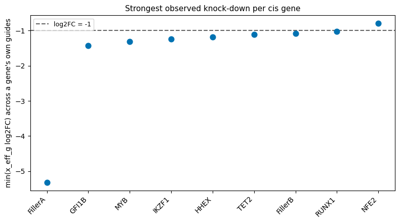

```python
fig, ax = plt.subplots(figsize=(8, 4.5))
x = np.arange(len(min_log2fc_df))
ax.scatter(x, min_log2fc_df["min_log2fc"], color="#0072B2", s=60, zorder=3)
ax.axhline(-1.0, color="#666666", lw=1.5, ls="--", label="log2FC = -1")
ax.set_xticks(x)
ax.set_xticklabels(min_log2fc_df["gene"], rotation=45, ha="right")
ax.set_ylabel("min(x_eff_g log2FC) across a gene's own guides", fontsize=10)
ax.set_title("Strongest observed knock-down per cis gene", fontsize=11)
ax.legend(fontsize=9)
fig.tight_layout()
plt.show()
```

## Density plots: x_true in log2FC space, coloured by guide

One row per named gene. Per-cell `x_true` (already a point estimate, `model.x_true`) converted to log2FC against that gene's own NTC reference (`log2fc = log2(x_true) - log2(x_ntc)`), grouped by guide — **every** guide targeting that gene gets its own curve (`guides = sorted(df["guide"].unique())`, not just the first/mean guide; each row's label includes the guide count so this is visible directly in the figure). The grey "NTC" curve is **gene- specific too**: it's that row's own gene's `log2fc` for cells with `target == 'ntc'` in *that gene's own model* — i.e. the GFI1B row's NTC curve is GFI1B's own expression in NTC cells, not some blend of all 7 genes' NTC expression. Pooling NTC across genes would be meaningless here: `x_ntc` is gene-specific by construction, so "log2FC" means something different in every row, and mixing them would combine unrelated quantities. Each gene gets one fixed hue (Okabe-Ito, colourblind-safe), with its own guides as light-to-dark shades of that hue — a categorical family per gene, sequential within it, never a cycled/rainbow assignment. Curves are **filled** (`alpha=0.4`) with a thin matching outline on top for a crisp edge, not bare outlines.

Each curve is **peak-normalised** (divided by its own max) rather than plotted as a true density. A strong, low-variance guide effect (e.g. a guide that collapses `x_true` to a narrow range around its knock-down level) produces a tall, narrow true-density spike that would otherwise visually swamp every wider, noisier curve on the same axes — peak normalisation trades that absolute-area information (which you can already get from `cis_guide_summary.csv`) for the thing this plot is actually for: comparing *where* each guide's/gene's distribution sits and how tight it is, at a common visual scale.

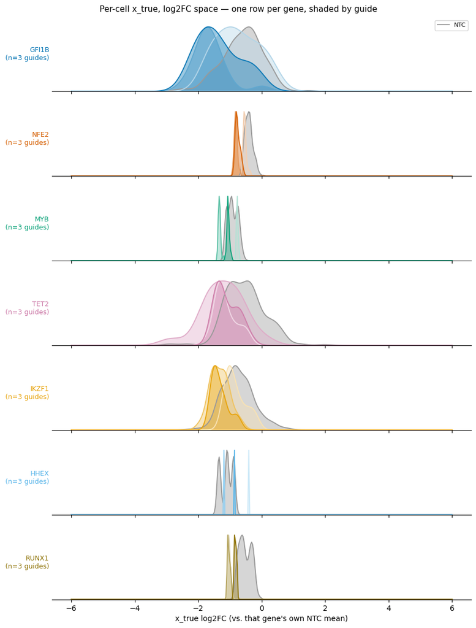

```python
GENE_HUES = {
    "GFI1B": "#0072B2",  # blue
    "NFE2":  "#D55E00",  # vermillion
    "MYB":   "#009E73",  # bluish green
    "TET2":  "#CC79A7",  # reddish purple
    "IKZF1": "#E69F00",  # orange
    "HHEX":  "#56B4E9",  # sky blue
    "RUNX1": "#8B6F00",  # dark gold (Okabe-Ito's yellow, darkened for line visibility on white)
}
NTC_GREY = "#999999"
FILL_ALPHA = 0.4


def gene_shades(base_hex: str, n: int):
    base_rgb = np.array(mcolors.to_rgb(base_hex))
    white = np.array([1.0, 1.0, 1.0])
    fracs = np.linspace(0.70, 0.05, n)  # lightest guide first, darkest (near base hue) last
    return [tuple(white * f + base_rgb * (1 - f)) for f in fracs]


def cell_log2fc_table(model, gene: str) -> pd.DataFrame:
    x_true = model.x_true
    x_true = x_true.detach().cpu().numpy() if isinstance(x_true, torch.Tensor) else np.asarray(x_true)
    cis_mod = model.get_modality("cis")
    mu_ntc_cis = cis_mod.posterior_samples_ntc["mu_ntc"]
    x_ntc = float(mu_ntc_cis.mean().item() if isinstance(mu_ntc_cis, torch.Tensor) else np.mean(mu_ntc_cis))
    return pd.DataFrame({
        "gene": gene,
        "guide": model.meta["guide"].values,
        "target": model.meta["target"].values,
        "log2fc": np.log2(x_true) - np.log2(x_ntc),
    })


from scipy.stats import gaussian_kde


def _peak_normalised(values: np.ndarray, grid: np.ndarray) -> np.ndarray:
    y = gaussian_kde(values)(grid)
    peak = y.max()
    return y / peak if peak > 0 else y


def _filled_curve(ax, grid, curve, color, alpha=FILL_ALPHA, lw=1.4, **kwargs):
    ax.fill_between(grid, curve, color=color, alpha=alpha, linewidth=0)
    ax.plot(grid, curve, color=color, lw=lw, **kwargs)


grid = np.linspace(-6, 6, 400)

fig, axes = plt.subplots(
    len(NAMED_GENES), 1, figsize=(9, 1.7 * len(NAMED_GENES)), sharex=True
)

for row, (gene, ax) in enumerate(zip(NAMED_GENES, axes)):
    full_df = cell_log2fc_table(cis_models[gene], gene)
    ntc_vals = full_df.loc[full_df["target"] == "ntc", "log2fc"].values
    df = full_df.loc[full_df["target"] == gene]
    guides = sorted(df["guide"].unique())
    shades = gene_shades(GENE_HUES[gene], len(guides))

    _filled_curve(ax, grid, _peak_normalised(ntc_vals, grid), NTC_GREY, label="NTC" if row == 0 else None)
    for guide, color in zip(guides, shades):
        vals = df.loc[df["guide"] == guide, "log2fc"].values
        if len(vals) < 2 or np.std(vals) == 0:
            continue
        _filled_curve(ax, grid, _peak_normalised(vals, grid), color)

    ax.set_ylabel(f"{gene}\n(n={len(guides)} guides)", rotation=0, ha="right",
                   va="center", fontsize=9, color=GENE_HUES[gene])
    ax.set_yticks([])
    ax.set_ylim(0, 1.15)
    for spine in ("top", "right", "left"):
        ax.spines[spine].set_visible(False)

axes[0].legend(loc="upper right", fontsize=8)
axes[-1].set_xlabel("x_true log2FC (vs. that gene's own NTC mean)", fontsize=10)
fig.suptitle("Per-cell x_true, log2FC space — one row per gene, shaded by guide", fontsize=11)
fig.tight_layout()
plt.show()
```

## Next steps

- `model.check_systematic_shift()` (compensation stage) before trusting `sum_factor_adj` on cells with unusually large shifts — see `publication_runs/common/run_compensation.py` for the reference pattern.
- `model.refit_sumfactor(covariates=[...])` after `fit_cis()`, to produce `sum_factor_refit` for `fit_trans()` — needs `x_true`, which is why it runs *after* this stage, not alongside `adjust_ntc_sum_factor()`.
- `fit_trans()` on whichever genes cleared the density/log2FC sanity checks above — see `docs/FIT_TRANS_GUIDE.md` and this repo's `publication_runs/domingo/` / `publication_runs/morris/` for full worked pipelines (ntc -> cis -> compensation -> trans -> permutation -> recapitulation) to copy `publication_runs/template_dataset/` from.